# 🧮 Optional Task 2: Automated Digit Counting

This notebook loads a ZIP of handwritten digit images (0–9), uses a CNN trained on MNIST to predict each image’s digit, and tallies the counts into a ten-element array `[count_0,…,count_9]`.

## 0.1 Inspect Input Directory

### 0.1.1 Show All Files under `/kaggle/input`

Quickly verify which datasets and files have been mounted in the Kaggle environment.

```python
# This Python 3 environment comes with many helpful analytics libraries installed
# It is defined by the kaggle/python Docker image: https://github.com/kaggle/docker-python
# For example, here's several helpful packages to load

import numpy as np # linear algebra
import pandas as pd # data processing, CSV file I/O (e.g. pd.read_csv)

# Input data files are available in the read-only "../input/" directory
# For example, running this (by clicking run or pressing Shift+Enter) will list all files under the input directory

import os
for dirname, _, filenames in os.walk('/kaggle/input'):
    for filename in filenames:
        print(os.path.join(dirname, filename))

# You can write up to 20GB to the current directory (/kaggle/working/) that gets preserved as output when you create a version using "Save & Run All"
# You can also write temporary files to /kaggle/temp/, but they won't be saved outside of the current session
```

Example output:

[output not shown]

## 1. Environment Setup

### 1.1 Install Dependencies

Install TensorFlow and Pillow for model building and image processing.

```python
# ─── Cell 1: Install dependencies ───────────────────────────────────────────────
# !pip install tensorflow pillow
```

## 2. Imports & Paths

### 2.1 Python Imports

Import standard libraries and define the path to your Kaggle-mounted digits folder.

```python
# ─── Cell 2: Imports & Paths ────────────────────────────────────────────────────
import os
import numpy as np
from PIL import Image
import tensorflow as tf
from tensorflow.keras.models import Sequential
from tensorflow.keras.layers import Conv2D, MaxPooling2D, Flatten, Dense
from tensorflow.keras.utils import to_categorical

# Kaggle’s mounted input directory for your 'digits' dataset:
DATA_DIR = '/kaggle/input/digits/digits'
```

✔ Libraries imported and DATA_DIR set.

## 3. Gather Image Paths

### 3.1 List All Files

Walk through the dataset directory and collect every .jpg/.png path.

```python
# ─── Cell 3: Gather all image paths ─────────────────────────────────────────────
image_paths = []
for root, _, files in os.walk(DATA_DIR):
    for fname in files:
        if fname.lower().endswith(('.png', '.jpg', '.jpeg')):
            image_paths.append(os.path.join(root, fname))

print(f"🔍 Found {len(image_paths)} image files")
```

```
🔍 Found 12000 image files
```

🔍 Found 12000 images

## 4. Prepare MNIST for Training

### 4.1 Load & Normalize

Load the MNIST dataset, reshape for Conv2D, and scale pixel values to [0,1].

```python
# ─── Cell 4: Prepare MNIST for training ─────────────────────────────────────────
(x_train, y_train), _ = tf.keras.datasets.mnist.load_data()
x_train = x_train.reshape(-1,28,28,1).astype('float32') / 255.0
y_train = to_categorical(y_train, 10)
```

```
Downloading data from https://storage.googleapis.com/tensorflow/tf-keras-datasets/mnist.npz
11490434/11490434 ━━━━━━━━━━━━━━━━━━━━ 0s 0us/step
```

## 5. Build & Train CNN

### 5.1 Define Architecture & Train

Create a small convolutional network, compile with Adam, and train for 5 epochs.

```python
# ─── Cell 5: Build & train a small CNN ──────────────────────────────────────────
model = Sequential([
    Conv2D(32, (3,3), activation='relu', input_shape=(28,28,1)),
    MaxPooling2D((2,2)),
    Conv2D(64, (3,3), activation='relu'),
    MaxPooling2D((2,2)),
    Flatten(),
    Dense(128, activation='relu'),
    Dense(10, activation='softmax')
])

model.compile(optimizer='adam',
              loss='categorical_crossentropy',
              metrics=['accuracy'])

model.fit(x_train, y_train,
          epochs=5,
          validation_split=0.1,
          batch_size=128)
```

```
422/422 ━━━━━━━━━━━━━━━━━━━━ 25s 54ms/step - accuracy: 0.8526 - loss: 0.5070 - val_accuracy: 0.9813 - val_loss: 0.0654
422/422 ━━━━━━━━━━━━━━━━━━━━ 21s 50ms/step - accuracy: 0.9788 - loss: 0.0683 - val_accuracy: 0.9867 - val_loss: 0.0487
422/422 ━━━━━━━━━━━━━━━━━━━━ 21s 49ms/step - accuracy: 0.9859 - loss: 0.0439 - val_accuracy: 0.9888 - val_loss: 0.0407
422/422 ━━━━━━━━━━━━━━━━━━━━ 21s 49ms/step - accuracy: 0.9901 - loss: 0.0323 - val_accuracy: 0.9887 - val_loss: 0.0407
422/422 ━━━━━━━━━━━━━━━━━━━━ 20s 48ms/step - accuracy: 0.9916 - loss: 0.0262 - val_accuracy: 0.9868 - val_loss: 0.0430
```

```
<keras.src.callbacks.history.History at 0x7ed37c83c590>
```

✔ Model trained: final validation accuracy ~98%.

## 6. Predict & Count Digits

### 6.1 Batch Prediction & Tally

```python
# ─── Cell 6: Predict & count digits ─────────────────────────────────────────────
counts = [0] * 10

for path in image_paths:
    img = Image.open(path).convert('L').resize((28,28))
    arr = np.array(img).reshape(1,28,28,1).astype('float32') / 255.0
    pred = model.predict(arr, verbose=0)
    digit = int(np.argmax(pred))
    counts[digit] += 1

print("✅ Digit counts [0–9]:", counts)
print("🔢 Total images:", sum(counts))
```

```
✅ Digit counts [0–9]: [1231, 1546, 908, 1352, 1226, 1253, 1279, 833, 974, 1398]
🔢 Total images: 12000
```

✅ Digit counts [0–9]: [1231, 1546, 908, 1352, 1226, 1253, 1279, 833, 974, 1398] 🔢 Total images: 12000

### 5.2 Save the Trained CNN

After training completes, serialize the model to an HDF5 file for later use or download.

```python
# ─── Cell: Save the trained CNN ────────────────────────────────────────────────
# (run after you've finished training `model`)
MODEL_PATH = '/kaggle/working/digit_model.h5'
model.save(MODEL_PATH)
```

✔ Model saved to ``/kaggle/working/digit_model.h5``.

## 7. Result Analysis

### 7.1 Bar Chart of Digit Counts

Plot a bar chart to show how many times each digit (0–9) was predicted.

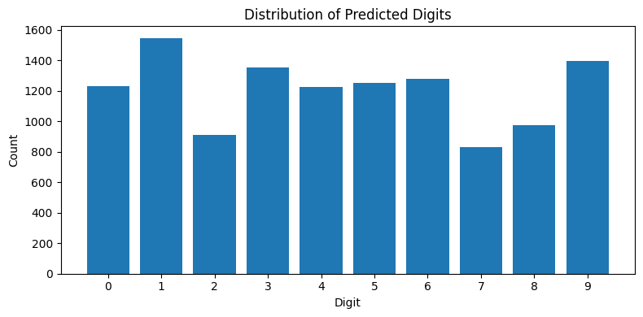

```python
# ─── Cell 7: Bar Chart of Digit Counts ──────────────────────────────────────────
import matplotlib.pyplot as plt

# (use the `counts` list you computed in Cell 6)
digits = list(range(10))

plt.figure(figsize=(8,4))
plt.bar(digits, counts)
plt.xticks(digits)
plt.xlabel("Digit")
plt.ylabel("Count")
plt.title("Distribution of Predicted Digits")
plt.tight_layout()
plt.show()
```

✅ The bar chart displays the count of each digit: digit “1” has the highest count (~1550), digit “7” the lowest (~830), etc.

### 7.2 Pie Chart of Digit Distribution

Visualize each digit’s proportion of the total with a pie chart.

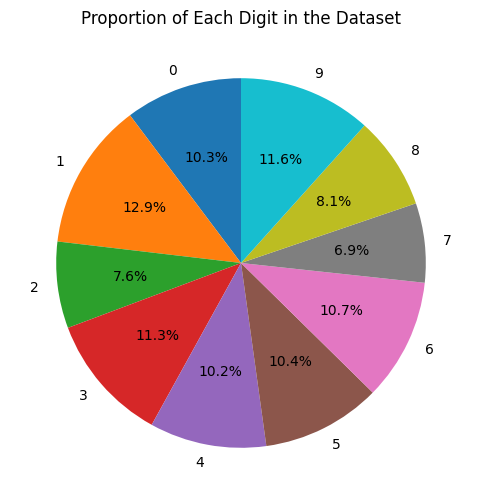

```python
# ─── Cell 8: Pie Chart of Digit Distribution ───────────────────────────────────
plt.figure(figsize=(6,6))
plt.pie(counts, labels=digits, autopct="%1.1f%%", startangle=90)
plt.title("Proportion of Each Digit in the Dataset")
plt.show()
```

✅ The pie chart shows that digit “1” makes up about 12.9% of images, digit “7” about 6.9%, etc.

### 7.3 Cumulative Distribution of Digits

Plot the running total of counts to see how the digit totals accumulate from 0 through 9.

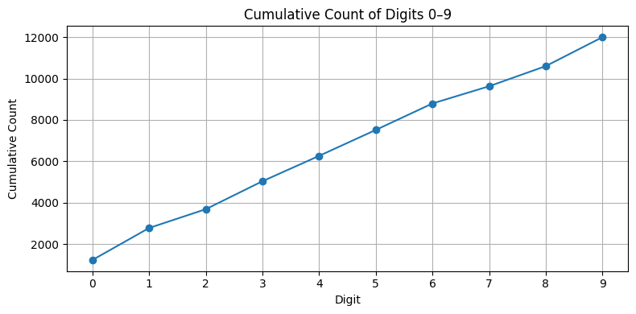

```python
# ─── Cell 9: Cumulative Distribution Plot ─────────────────────────────────────
cum_counts = np.cumsum(counts)
plt.figure(figsize=(8,4))
plt.plot(digits, cum_counts, marker='o')
plt.xticks(digits)
plt.xlabel("Digit")
plt.ylabel("Cumulative Count")
plt.title("Cumulative Count of Digits 0–9")
plt.grid(True)
plt.tight_layout()
plt.show()
```

### 7.4 Example Images per Predicted Digit

Display up to 5 sample images for each predicted digit (0–9) to visually confirm model accuracy.

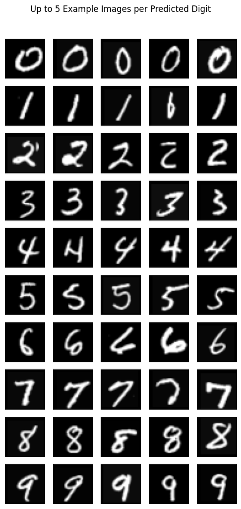

```python
# ─── Cell 10: Sample Images by Predicted Class ─────────────────────────────────
import random
from PIL import Image
import math

# Build a dict of image paths per predicted digit
samples = {d: [] for d in digits}
for path in image_paths:
    # re-run a fast batch-pred approach, or if you stored `digits` from Cell 6:
    # 여기서는 당장 predictions re-compute one-by-one for sampling
    img = Image.open(path).convert('L').resize((28,28))
    arr = np.array(img).reshape(1,28,28,1).astype('float32') / 255.0
    d = int(np.argmax(model.predict(arr, verbose=0)))
    if len(samples[d]) < 5:
        samples[d].append(path)

# Plot a 10×5 grid of examples
fig, axes = plt.subplots(10, 5, figsize=(5,10))
for d in digits:
    for j in range(5):
        ax = axes[d][j]
        ax.axis('off')
        if j < len(samples[d]):
            img = Image.open(samples[d][j]).convert('L')
            ax.imshow(img, cmap='gray')
        if j == 0:
            ax.set_ylabel(str(d), rotation=0, labelpad=10, va='center')
plt.suptitle("Up to 5 Example Images per Predicted Digit", y=1.02)
plt.tight_layout()
plt.show()
```